# Analiza zawartości biblioteki Netflix

## Wstęp

Dataset, który wykorzystujemy w naszym projekcie zawiera informacje dotyczące filmów i seriali znajdujących się na platformie Netflix

Dane zostały pobrane ze strony Kaggle (https://www.kaggle.com/datasets/shivamb/netflix-shows)

Dataset składa się z 8807 unikalnych wartości i zawiera następujące kolumny:

- show_id (unikalne ID)
- type (identyfikator - film/serial)
- title (tytuł)
- director (reżyser)
- cast (zaangażowani aktorzy)
- country (kraj produkcji)
- date_added (data dodania na platformę)
- release_year (rok wydania)
- rating (grupa docelowa)
- duration (długość filmu/ilość sezonów serialu)
- listed_in (gatunek)
- description (opis)

### Importowanie bibliotek

```python
import pandas as pd
import numpy as np
import matplotlib.pyplot as plt
import seaborn as sns
```

### Wczytanie danych oraz przykładowe wiersze

```python
df = pd.read_csv('netflix_titles.csv')
df.head()
```

|  | show_id | type | title | director | cast | country | date_added | release_year | rating | duration | listed_in | description |
| --- | --- | --- | --- | --- | --- | --- | --- | --- | --- | --- | --- | --- |
| 0 | s1 | Movie | Dick Johnson Is Dead | Kirsten Johnson | NaN | United States | September 25, 2021 | 2020 | PG-13 | 90 min | Documentaries | As her father nears the end of his life, filmm... |
| 1 | s2 | TV Show | Blood & Water | NaN | Ama Qamata, Khosi Ngema, Gail Mabalane, Thaban... | South Africa | September 24, 2021 | 2021 | TV-MA | 2 Seasons | International TV Shows, TV Dramas, TV Mysteries | After crossing paths at a party, a Cape Town t... |
| 2 | s3 | TV Show | Ganglands | Julien Leclercq | Sami Bouajila, Tracy Gotoas, Samuel Jouy, Nabi... | NaN | September 24, 2021 | 2021 | TV-MA | 1 Season | Crime TV Shows, International TV Shows, TV Act... | To protect his family from a powerful drug lor... |
| 3 | s4 | TV Show | Jailbirds New Orleans | NaN | NaN | NaN | September 24, 2021 | 2021 | TV-MA | 1 Season | Docuseries, Reality TV | Feuds, flirtations and toilet talk go down amo... |
| 4 | s5 | TV Show | Kota Factory | NaN | Mayur More, Jitendra Kumar, Ranjan Raj, Alam K... | India | September 24, 2021 | 2021 | TV-MA | 2 Seasons | International TV Shows, Romantic TV Shows, TV ... | In a city of coaching centers known to train I... |

### Sprawdzenie brakujących danych oraz ich typu

```python
df.info()
```

```
<class 'pandas.core.frame.DataFrame'>
RangeIndex: 8807 entries, 0 to 8806
Data columns (total 12 columns):
 #   Column        Non-Null Count  Dtype
---  ------        --------------  -----
 0   show_id       8807 non-null   object
 1   type          8807 non-null   object
 2   title         8807 non-null   object
 3   director      6173 non-null   object
 4   cast          7982 non-null   object
 5   country       7976 non-null   object
 6   date_added    8797 non-null   object
 7   release_year  8807 non-null   int64
 8   rating        8803 non-null   object
 9   duration      8804 non-null   object
 10  listed_in     8807 non-null   object
 11  description   8807 non-null   object
dtypes: int64(1), object(11)
memory usage: 825.8+ KB
```

#### Jak widzimy, większość danych to typu object, co oznacza, że są to dane tekstowe, mamy tylko jedną kolumnę, która jako typ danych przyjmuje wartość int64 - 'release_year'

```python
df.isnull().sum()
```

```
show_id            0
type               0
title              0
director        2634
cast             825
country          831
date_added        10
release_year       0
rating             4
duration           3
listed_in          0
description        0
dtype: int64
```

#### Ze względu na to, że w naszym datasecie jest wiele wartości nullowych, zdecydowaliśmy, że nie będziemy usuwać całych wierszy, gdzie występują brakujące dane, gdyż wtedy stracilibyśmy dużą ilość danych co wpłynęło by negatywnie na analizę innych kolumn. Wartości typu NaN/null będziemy obsługiwać ręcznie.

### Wstępne przetworzenie danych

#### Usunięcie NA z duration oraz usunięcie kolumny 'show_id'

```python
df.dropna(subset=['duration'], inplace=True)
df.drop('show_id', axis=1, inplace=True)
```

#### Podział datasetu na filmy i seriale, oraz zmiana typu oraz nazwy kolumny duration na seasons/minutes [int]

```python
movies_df = df[df['type'] == 'Movie'].copy()
movies_df.rename(columns={'duration': 'minutes'}, inplace=True)
movies_df['minutes'] = movies_df['minutes'].replace(' min', '', regex=True).astype(int)

shows_df = df[df['type'] == 'TV Show'].copy()
shows_df.rename(columns={'duration': 'seasons'}, inplace=True)
shows_df['seasons'] = shows_df['seasons'].replace(' Season', '', regex=True)
shows_df['seasons'] = shows_df['seasons'].replace('s', '', regex=True)
shows_df['seasons'] = shows_df['seasons'].astype(int)
```

## Analiza danych dla całego dataset

### Procentowa wartość ilości filmów i seriali

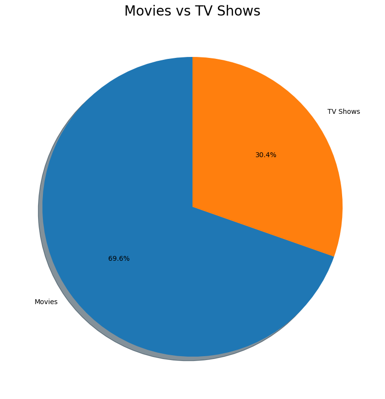

```python
df.groupby('type').count()
plt.figure(figsize=(10, 10))
plt.pie(df.groupby('type').count()['title'], labels=['Movies', 'TV Shows'], autopct='%1.1f%%', startangle=90, shadow=True)
plt.title('Movies vs TV Shows', fontsize=20)
plt.show()
```

### Top 10 reżyserów, którzy stworzyli najwięcej filmów lub seriali dostępnych na platformie Netflix

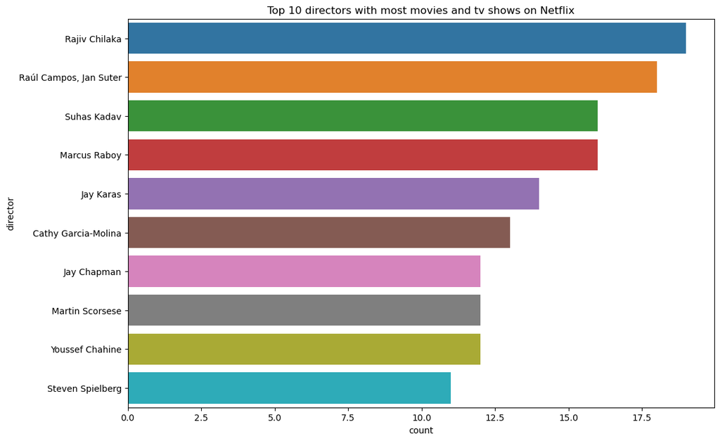

```python
plt.figure(figsize=(12, 8))
sns.countplot(y='director', data=df, order=df['director'].value_counts().iloc[:10].index,)
plt.title('Top 10 directors with most movies and tv shows on Netflix')
plt.show()
```

### Kraj produkcji filmów lub seriali stworzonych przez powyższych reyżserów

```python
directors = df['director'].value_counts().iloc[:10]
directors
countries = []
for director in directors.index:
    countries.append((director,df[df['director'] == director]['country'].iloc[0]))
    if pd.isnull(countries[-1][1]):
        countries[-1] = (director,'India')
countries = pd.DataFrame(countries, columns=['director', 'country'])
countries
```

|  | director | country |
| --- | --- | --- |
| 0 | Rajiv Chilaka | India |
| 1 | Raúl Campos, Jan Suter | Mexico |
| 2 | Suhas Kadav | India |
| 3 | Marcus Raboy | United States |
| 4 | Jay Karas | United States |
| 5 | Cathy Garcia-Molina | Philippines |
| 6 | Jay Chapman | United States |
| 7 | Martin Scorsese | United States |
| 8 | Youssef Chahine | Egypt |
| 9 | Steven Spielberg | United States |

### Ilość produkcji wypuszonych na rynek oraz platformę Netflix w przeciągu lat

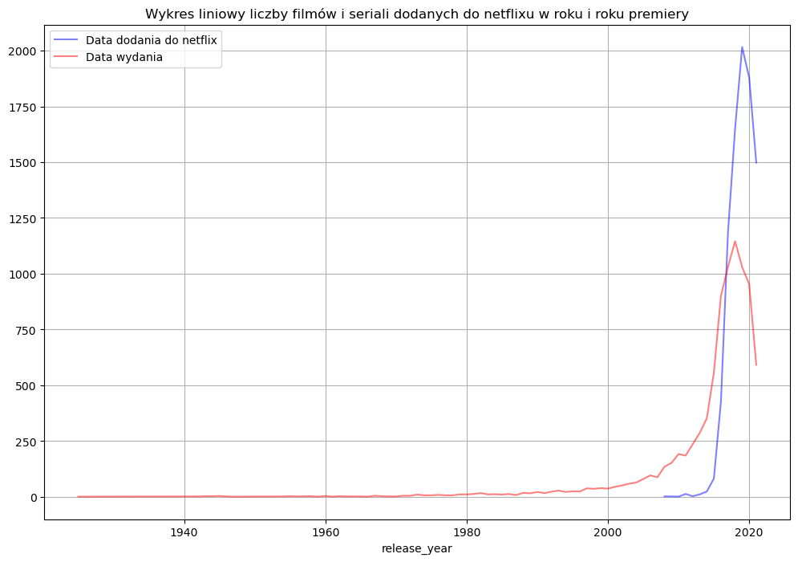

```python
netflix_df = df.copy()
netflix_df.dropna(subset=['date_added',"release_year"], inplace=True)
netflix_df['date_added'] = netflix_df['date_added'].str.slice(-4).astype(int)
netflix_df.groupby('date_added')['title'].count().plot(kind='line', figsize=(12, 8), color='blue', alpha=0.5, )
netflix_df.groupby('release_year')['title'].count().plot(kind='line', figsize=(12, 8), color='red', alpha=0.5, )
plt.grid()
plt.title('Wykres liniowy liczby filmów i seriali dodanych do netflixu w roku i roku premiery')
plt.legend(['Data dodania do netflix', 'Data wydania'])
```

### Top 20 krajów, z których pochodzą produkcje dostępne na platformie Netflix

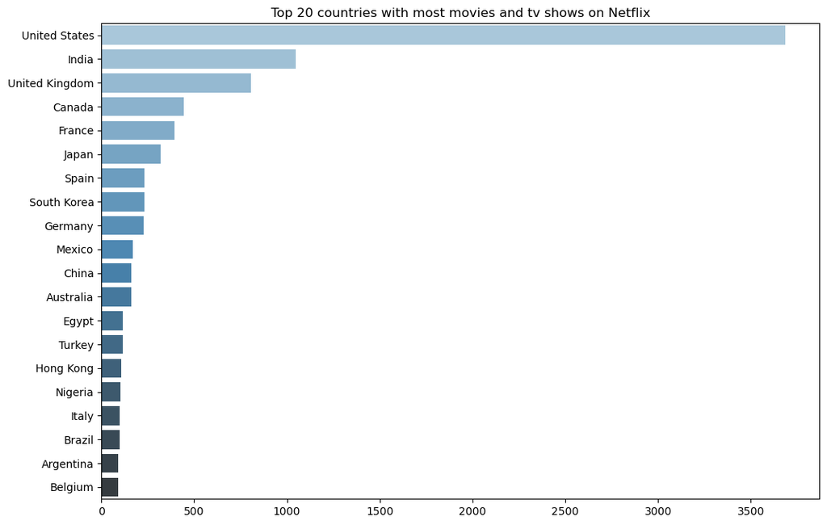

```python
countries = []
for country in df['country']:
    if pd.isnull(country):
        continue
    countries.extend(country.split(', '))
countries = np.array(countries)
countries = pd.DataFrame(countries, columns=['country'])
countries = countries['country'].value_counts()
plt.figure(figsize=(12, 8))
sns.barplot(x=countries.iloc[:20].values, y=countries.iloc[:20].index, palette='Blues_d')
plt.title('Top 20 countries with most movies and tv shows on Netflix')
plt.show()
```

### Top 20 aktorów, którzy wystąpili w największej ilości produkcji dostępnych na platformie Netflix

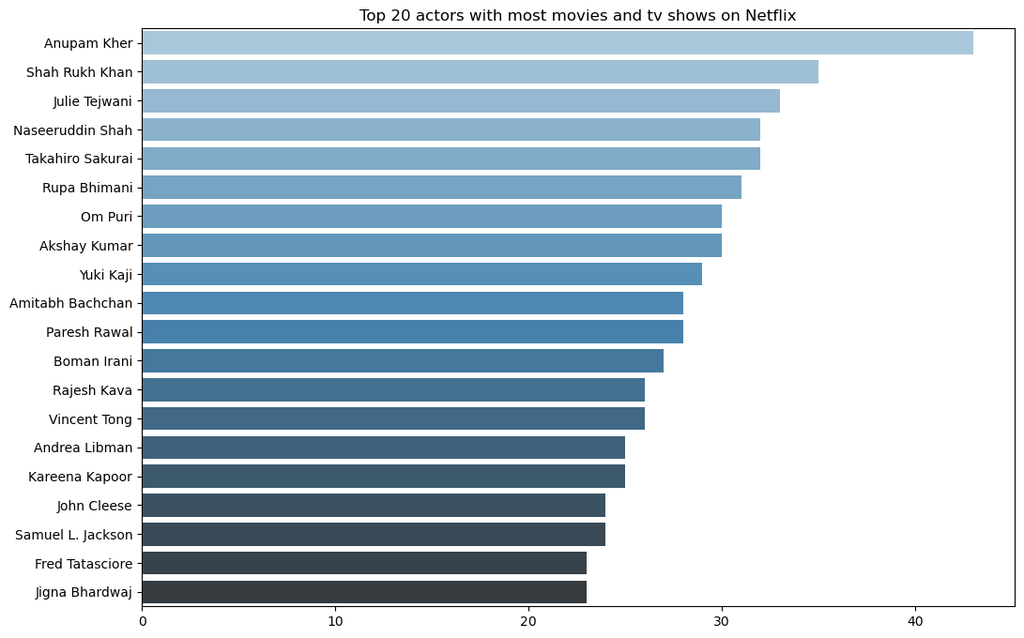

```python
actors_df = df.copy()
actors_df.dropna(subset=['cast'], inplace=True)
actors = []
for actor in actors_df['cast']:
    actors.extend(actor.split(', '))
actors = np.array(actors)
actors = pd.DataFrame(actors, columns=['actor'])
actors = actors['actor'].value_counts()
plt.figure(figsize=(12, 8))
sns.barplot(x=actors.iloc[:20].values, y=actors.iloc[:20].index, palette='Blues_d')
plt.title('Top 20 actors with most movies and tv shows on Netflix')
plt.show()
```

## Analiza danych dla dataset z filmami

### Top 10 gatunków filmowych na platformie Netflix

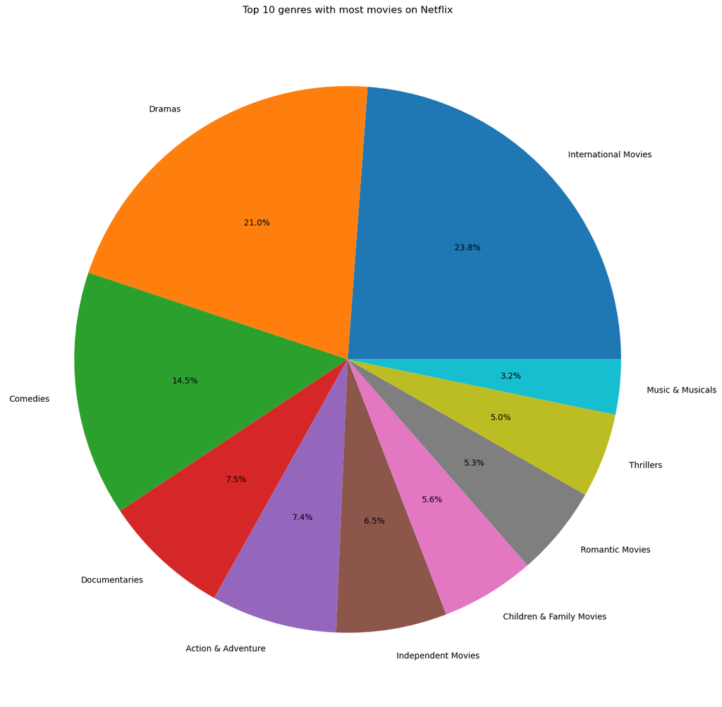

```python
genres = []
genre_df = movies_df.copy()
genre_df.dropna(subset=['listed_in'], inplace=True)
for genre in genre_df['listed_in']:
    genres.extend(genre.split(', '))
genres = np.array(genres)
genres = pd.DataFrame(genres, columns=['genre'])
genres = genres['genre'].value_counts()
plt.figure(figsize=(15, 15))
plt.pie(genres.iloc[:10].values, labels=genres.iloc[:10].index, autopct='%1.1f%%')
plt.title('Top 10 genres with most movies on Netflix')
plt.show()
```

### Top 10 najdłuższych filmów dostępnych na platformie Netflix

```python
movies_df.sort_values('minutes', ascending=False).head(10)
```

|  | type | title | director | cast | country | date_added | release_year | rating | minutes | listed_in | description |
| --- | --- | --- | --- | --- | --- | --- | --- | --- | --- | --- | --- |
| 4253 | Movie | Black Mirror: Bandersnatch | NaN | Fionn Whitehead, Will Poulter, Craig Parkinson... | United States | December 28, 2018 | 2018 | TV-MA | 312 | Dramas, International Movies, Sci-Fi & Fantasy | In 1984, a young programmer begins to question... |
| 717 | Movie | Headspace: Unwind Your Mind | NaN | Andy Puddicombe, Evelyn Lewis Prieto, Ginger D... | NaN | June 15, 2021 | 2021 | TV-G | 273 | Documentaries | Do you want to relax, meditate or sleep deeply... |
| 2491 | Movie | The School of Mischief | Houssam El-Din Mustafa | Suhair El-Babili, Adel Emam, Saeed Saleh, Youn... | Egypt | May 21, 2020 | 1973 | TV-14 | 253 | Comedies, Dramas, International Movies | A high school teacher volunteers to transform ... |
| 2487 | Movie | No Longer kids | Samir Al Asfory | Said Saleh, Hassan Moustafa, Ahmed Zaki, Youne... | Egypt | May 21, 2020 | 1979 | TV-14 | 237 | Comedies, Dramas, International Movies | Hoping to prevent their father from skipping t... |
| 2484 | Movie | Lock Your Girls In | Fouad El-Mohandes | Fouad El-Mohandes, Sanaa Younes, Sherihan, Ahm... | NaN | May 21, 2020 | 1982 | TV-PG | 233 | Comedies, International Movies, Romantic Movies | A widower believes he must marry off his three... |
| 2488 | Movie | Raya and Sakina | Hussein Kamal | Suhair El-Babili, Shadia, Abdel Moneim Madboul... | NaN | May 21, 2020 | 1984 | TV-14 | 230 | Comedies, Dramas, International Movies | When robberies and murders targeting women swe... |
| 166 | Movie | Once Upon a Time in America | Sergio Leone | Robert De Niro, James Woods, Elizabeth McGover... | Italy, United States | September 1, 2021 | 1984 | R | 229 | Classic Movies, Dramas | Director Sergio Leone's sprawling crime epic f... |
| 7932 | Movie | Sangam | Raj Kapoor | Raj Kapoor, Vyjayanthimala, Rajendra Kumar, La... | India | December 31, 2019 | 1964 | TV-14 | 228 | Classic Movies, Dramas, International Movies | Returning home from war after being assumed de... |
| 1019 | Movie | Lagaan | Ashutosh Gowariker | Aamir Khan, Gracy Singh, Rachel Shelley, Paul ... | India, United Kingdom | April 17, 2021 | 2001 | PG | 224 | Dramas, International Movies, Music & Musicals | In 1890s India, an arrogant British commander ... |
| 4573 | Movie | Jodhaa Akbar | Ashutosh Gowariker | Hrithik Roshan, Aishwarya Rai Bachchan, Sonu S... | India | October 1, 2018 | 2008 | TV-14 | 214 | Action & Adventure, Dramas, International Movies | In 16th-century India, what begins as a strate... |

## Analiza danych dataset z serialami

### Top 10 gatunków seriali na platformie Netflix

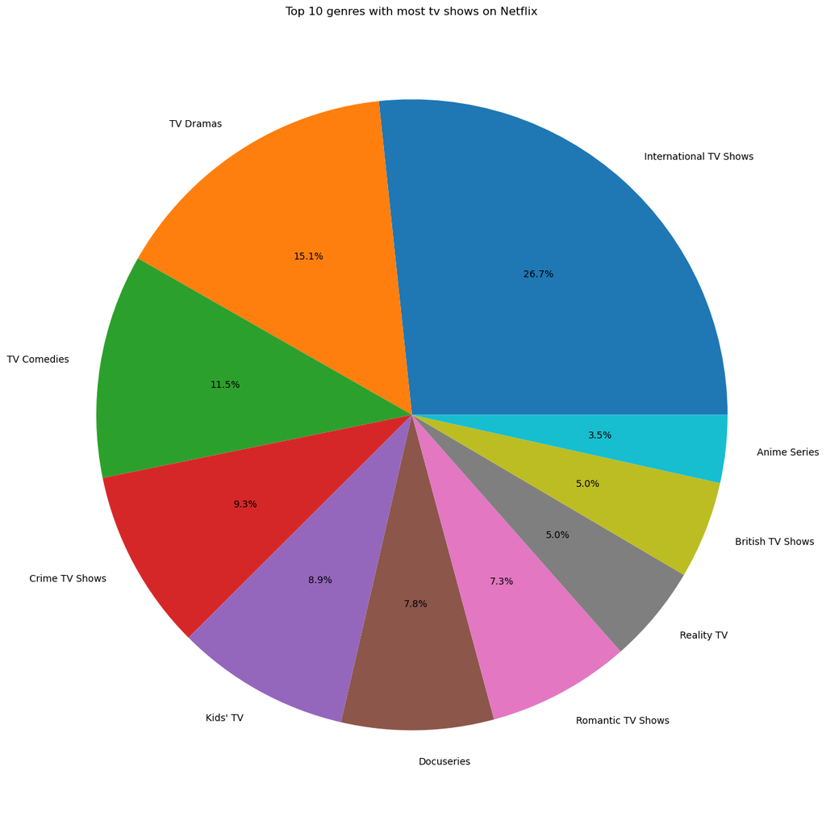

```python
genres = []
genre_df = shows_df.copy()
genre_df.dropna(subset=['listed_in'], inplace=True)
for genre in genre_df['listed_in']:
    genres.extend(genre.split(', '))
genres = np.array(genres)
genres = pd.DataFrame(genres, columns=['genre'])
genres = genres['genre'].value_counts()
plt.figure(figsize=(15, 15))
plt.pie(genres.iloc[:10].values, labels=genres.iloc[:10].index, autopct='%1.1f%%')
plt.title('Top 10 genres with most tv shows on Netflix')
plt.show()
```

### Top 10 seriali z największą ilością sezonów

```python
shows_df.sort_values('seasons', ascending=False).head(10)
```

|  | type | title | director | cast | country | date_added | release_year | rating | seasons | listed_in | description |
| --- | --- | --- | --- | --- | --- | --- | --- | --- | --- | --- | --- |
| 548 | TV Show | Grey's Anatomy | NaN | Ellen Pompeo, Sandra Oh, Katherine Heigl, Just... | United States | July 3, 2021 | 2020 | TV-14 | 17 | Romantic TV Shows, TV Dramas | Intern (and eventual resident) Meredith Grey f... |
| 2423 | TV Show | Supernatural | Phil Sgriccia | Jared Padalecki, Jensen Ackles, Mark Sheppard,... | United States, Canada | June 5, 2020 | 2019 | TV-14 | 15 | Classic & Cult TV, TV Action & Adventure, TV H... | Siblings Dean and Sam crisscross the country, ... |
| 4798 | TV Show | NCIS | NaN | Mark Harmon, Michael Weatherly, Pauley Perrett... | United States | July 1, 2018 | 2017 | TV-14 | 15 | Crime TV Shows, TV Dramas, TV Mysteries | Follow the quirky agents of the NCIS – the Nav... |
| 1354 | TV Show | Heartland | NaN | Amber Marshall, Michelle Morgan, Graham Wardle... | Canada | February 1, 2021 | 2019 | TV-14 | 13 | TV Dramas | Spunky teenager Amy is reeling from the sudden... |
| 4220 | TV Show | COMEDIANS of the world | NaN | Neal Brennan, Chris D'Elia, Nicole Byer, Nick ... | United States | January 1, 2019 | 2019 | TV-MA | 13 | Stand-Up Comedy & Talk Shows, TV Comedies | This global stand-up comedy series features a ... |
| 7847 | TV Show | Red vs. Blue | NaN | Burnie Burns, Jason Saldaña, Gustavo Sorola, G... | United States | NaN | 2015 | NR | 13 | TV Action & Adventure, TV Comedies, TV Sci-Fi ... | This parody of first-person shooter games, mil... |
| 4964 | TV Show | Trailer Park Boys | NaN | Mike Smith, John Paul Tremblay, Robb Wells, Jo... | Canada | March 30, 2018 | 2018 | TV-MA | 12 | Classic & Cult TV, Crime TV Shows, Internation... | Follow the booze-fueled misadventures of three... |
| 5412 | TV Show | Criminal Minds | NaN | Mandy Patinkin, Joe Mantegna, Thomas Gibson, S... | United States, Canada | June 30, 2017 | 2017 | TV-14 | 12 | Crime TV Shows, TV Dramas, TV Mysteries | This intense police procedural follows a group... |
| 6795 | TV Show | Frasier | NaN | Kelsey Grammer, Jane Leeves, David Hyde Pierce... | United States | NaN | 2003 | TV-PG | 11 | Classic & Cult TV, TV Comedies | Frasier Crane is a snooty but lovable Seattle ... |
| 6456 | TV Show | Cheers | NaN | Ted Danson, Rhea Perlman, George Wendt, John R... | United States | July 1, 2017 | 1992 | TV-PG | 11 | Classic & Cult TV, TV Comedies | Sam Malone, an ex-baseball player turned bar o... |